# A3: SPL Library Checkouts

### Introduction

This data is from the Seattle Public Library system, covering only 2022 and the first month of 2023. One facet of this data that is interesting is the number of digital items checked out versus the number of physical items checked out, specifically in a comparison between physical books and audiobooks. I am choosing to look at this question through the lens of one of my favorite authors growing up, Agatha Christie, whose books I read both as physical copies and as audiobooks (though in the King County Library System rather than SPL).

I will compare physical book checkouts of some of Christie’s most popular books (specifically “Murder on the Orient Express”, “And Then There Were None”, and “The Mysterious Affair at Styles”) into one that I really enjoy and feel is less appreciated than more well-known books called “Cards on the Table.”

I will also be comparing the distribution of checkouts for “Murder on the Orient Express” across multiple mediums to see if my own reading patterns that focused on audiobooks and physical books were similar at the Seattle city level.

Most generally, I will compare the average number of checkouts per item by medium to compare if physical media are more frequently read than digital media, or vice versa, across the entire dataset and the variety of different mediums that the Seattle Public Libraries offer.

### Summary Information

There were a grand total of 9196991 items checked out across 2022 and Jan 2023. The most frequently checked out book from SPL was titled “The House of Broken Angels.” The month that had the highest number of checkouts in total was number 1. One interesting comparison is between physical books and audiobooks; audiobooks, on average, were checked out 4.76 times per month, while physical books were checked out 2.85 times per month. The most popular Agatha Christie book was checked out 116 times in a single month. Across all of Christie’s books, the most popular title in 2022 was “The Mysterious Affair at Styles: Hercule Poirot Series, Book 1” and the most popular format was an audiobook.

### The Dataset

- Who collected/published the data?

This data was collected by the Seattle Public Library internally on their own libraries.

- What are the parameters of the data (dates, number of checkouts, kinds of books, etc.)?

The entire dataset collected by SPL has 42 million data points and reaches back to 2005, but the subset used here covers only 2022 and Jan 2023 and has only about 2.7 million data points. It covers physical books, video and sound recordings, ‘checkouts’ of library amenities like headphones, audiobooks/ebooks and other digital media, and many more types of item.

- How was the data collected or generated?

This data was collected through a variety of services. Physical items were recorded by merging historic physical item checkouts from Legrady artwork data archives with the current system implemented in 2016, Horizon ILS. Data on digital checkouts is provided by media vendors like Overdrive, hoopla, Freegal, and RBDigital.

- Why was the data collected?

This data was collected as part of the “Seattle Open Data” program, which collects data published by city departments for anyone to use or share. This data was collected to make it public knowledge and let average people understand SPL lending.

- How many observations (rows) are in your data?

There are 2757014 observations in this dataset.

- How many features (columns) are in the data?

There are 12 features of this data, including material type, title, creator, publisher, and publication date.

- What, if any, ethical questions do you need to consider when working with this data?

Because this is a list of anonymous library book checkouts, there are not major ethical questions to consider in the collection of the data. However, this data could easily be used to push funding towards the more popular titles or mediums and continue the process of currently less-popular media remaining less popular in thte future. Perhaps a glaring omission is the location at which these books were checked out, which might offer more information on class or race in use of the library system.

- What are possible limitations or problems with this data? (at least 200 words)

There are several limitations in this dataset. Renewals of library items are not counted as a ‘checkout’ for purposes of this data, which means that a common understanding of renewals of checking a book out again does not apply here. There are many titles that are missing subject headings due to not having a record in the system before 2016 and subsequently not having its description merged into this data. Many of the publication dates are estimated, cover multiple years, or draw on copyright or printing dates instead of a true publication date, making these dates more difficult to compare. As a database of checkouts only, this does not tell us anything about the items that SPL has in its possession but were not checked out in 2022 (and which would have checkouts equal to 0 in each month), biasing averages (for example, the number of times each material type was checked out) upward and shifting trend lines when a 0-checkout month is not included and is instead skipped over as an average of the two neighboring months. The specific sub-dataset I am using is only the last approximate year, which means it does not allow checking if the patterns found in this data are unique to 2022 or are a long-term trend going back to 2005.

### First Trends Over Time Chart

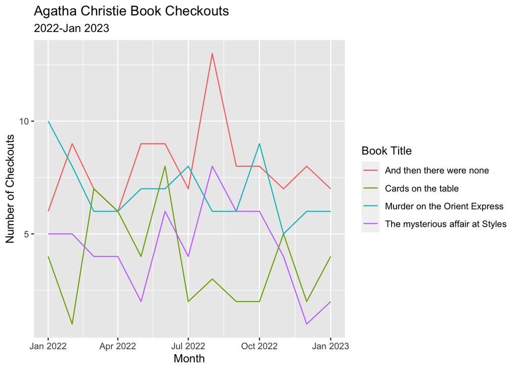

This graph demonstrates the variation in the number of physical book checkouts over time for three major Agatha Christie books (And Then There Were None, Murder on the Orient Express, Mysterious Affair at Styles) and one book, called “Cards on the Table,” that I personally enjoy but is not included on best or most popular Agatha Christie book lists. I wanted to see if the most well-known Christie books were significantly more checked out than a less well-known book. In many months (Jan-Feb and Jul-Oct 2022) “Cards on the Table did indeed have the lowest number of physical book checkouts, but in other months (especially Mar-June 2022) actually exceeded the number of checkouts of”The Mysterious Affair at Styles.” “And Then There Were None” was consistently the book checked out most frequently of these four, only being surpassed by “Murder on the Orient Express” in January, July, and October 2022.

### Second Trends Over Time Chart

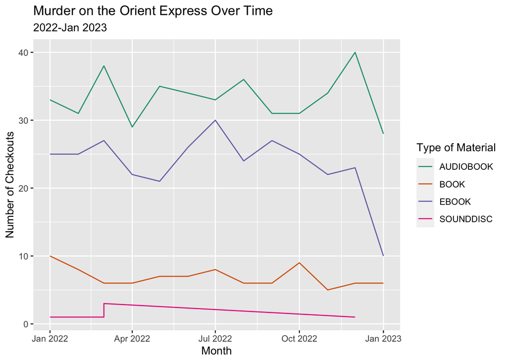

This is a line graph showing checkouts of “Murder on the Orient Express” between Jan 2022 and Jan 2023. It is included to show differences in the type of media most frequently used to access this particular book. It includes the soundtrack for the “Murder on the Orient Express” movie to set a baseline for other popular media associated with the book. The overall most popular material type was audiobooks, which in every month had the highest number of checkouts. This is fairly closely followed by the checkouts of ebooks, which varied between twenty and thirty checkouts per month. Actual physical books had a low but fairly consistent number of checkouts throughout this year, while ebooks and audiobooks varied much more month-to-month and both saw a large decline of about ten fewer checkouts in January 2023. These are all consistently more popular than the affiliated soundtrack, however, which never broke five checkouts per month.

### Your Choice

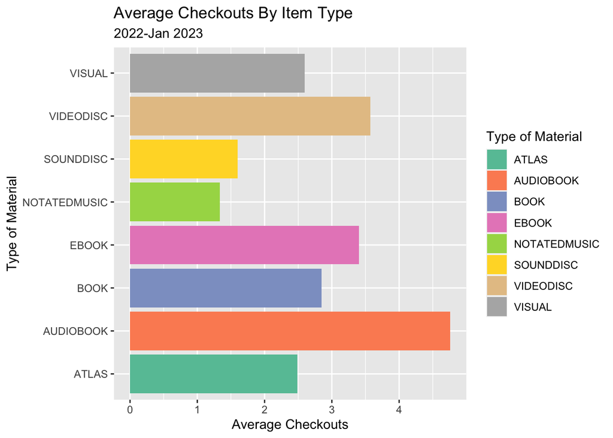

This is a bar chart that shows average number of checkouts per item based on their item type. It is included to compare the frequency of checkouts across different item types throughout the entire dataset, as a more general assessment of this distribution than for specific Agatha Christie books. On average, a given audiobook that was checked out in this time period was checked out more than four times, while an ebook was only checked out on average slightly more than three times and a physical book fewer than three times per month. Sheet music was the most infrequently checked out item on average of the types included here, with each item checked out less than twice per month. Surprisingly, the rate of checkouts for atlases and for visual media, which are less associated with the general functioning of a library, were checked out more times on average than sound discs and were overall fairly similar to the rates of physical book checkouts, which are seen as core to library functionality. Audiobooks were checked out the most times per month on average, which is similar to the result found for “Murder on the Orient Express” specifically.